# clean_sacpas_data

Cat

2022-08-05

# Read in data

Files come from SacPas:

- MigrationTiming = (https://www.cbr.washington.edu/sacramento/data/query_hrt.html)[https://www.cbr.washington.edu/sacramento/data/query_hrt.html]
- Salvage = (“https://www.cbr.washington.edu/sacramento/data/query_salvage_hrt.html”)[“https://www.cbr.washington.edu/sacramento/data/query_salvage_hrt.html]

See queries:

```r
kbl(table <- data.frame(URL = c("MigrationTiming", "MigrationTiming", "MigrationTiming", "Salvage"),
                        Location = c("Chipps Island Trawls", "Sacramento Beach Seines Combined", "Sacramento Trawls (@ Sherwood Harbor)", NA),
                        SpeciesRun = "Chinook, Spring, Unclipped",
                        NumberYears = c(25,25,25,25),
                        Options = c("Catch Index", "Catch Index", "Catch Index", "Historical Timing"))) %>%
  kable_styling()
```

| URL | Location | SpeciesRun | NumberYears | Options |
| --- | --- | --- | --- | --- |
| MigrationTiming | Chipps Island Trawls | Chinook, Spring, Unclipped | 25 | Catch Index |
| MigrationTiming | Sacramento Beach Seines Combined | Chinook, Spring, Unclipped | 25 | Catch Index |
| MigrationTiming | Sacramento Trawls (@ Sherwood Harbor) | Chinook, Spring, Unclipped | 25 | Catch Index |
| Salvage | NA | Chinook, Spring, Unclipped | 25 | Historical Timing |

SacPas files

```r
filenames <- list.files("data_raw/", pattern="sacpas_unclipped_sr_chn*", full.names=TRUE)
file <- read_csv("data_raw/sacpas_unclipped_sr_chn_index_seine.csv", col_names =TRUE)

sr_list = lapply(filenames, read_csv)
sr_list2 = lapply(sr_list, `[`, -c(1:3),)
sr_mig0 <- bind_rows(sr_list2, .id = "column_label")
```

Other files

```r
wytype = read_csv("data_raw/WYType.csv") %>%
  janitor::clean_names()
```

# Clean data

## timing

```r
sr_mig <- sr_mig0 %>%
  janitor::clean_names() %>%
  mutate(across(.cols = contains("date"), lubridate::mdy)) %>%
  mutate(column_label = case_when(column_label == 1 ~ "Chipps",
                                  column_label == 2 ~ "SacBeach",
                                  column_label == 3 ~ "SacTrawlCI",
                                  column_label == 4 ~ "Salvage")) %>%
  rename(survey = column_label,
         broodyear = brood_year,
         date_first = first_passage_date,
         date_5 = x5_percent_passage_date,
         date_10 = x10_percent_passage_date,
         date_25 = x25_percent_passage_date,
         date_50 = x50_percent_passage_date,
         date_75 = x75_percent_passage_date,
         date_90 = x90_percent_passage_date,
         date_95 = x95_percent_passage_date,
         date_last = last_passage_date) %>%
  mutate(wy = year(date_last),
         survey = as.factor(survey)) %>%
  mutate(broodyear = ifelse(is.na(broodyear), wy-1, broodyear)) %>%
  select(survey:date_last,wy, expanded_salvage) %>%
  select(survey, wy, broodyear, everything())

str(sr_mig)
```

```
## tibble [97 × 13] (S3: tbl_df/tbl/data.frame)
##  $ survey          : Factor w/ 4 levels "Chipps","SacBeach",..: 1 1 1 1 1 1 1 1 1 1 ...
##  $ wy              : num [1:97] 2021 2020 2019 2018 2017 ...
##  $ broodyear       : chr [1:97] "2020" "2019" "2018" "2017" ...
##  $ date_first      : Date[1:97], format: "2021-03-30" "2020-03-23" ...
##  $ date_5          : Date[1:97], format: "2021-04-09" "2020-04-06" ...
##  $ date_10         : Date[1:97], format: "2021-04-18" "2020-04-06" ...
##  $ date_25         : Date[1:97], format: "2021-04-19" "2020-04-09" ...
##  $ date_50         : Date[1:97], format: "2021-04-22" "2020-04-16" ...
##  $ date_75         : Date[1:97], format: "2021-04-27" "2020-04-24" ...
##  $ date_90         : Date[1:97], format: "2021-05-04" "2020-05-01" ...
##  $ date_95         : Date[1:97], format: "2021-05-10" "2020-05-08" ...
##  $ date_last       : Date[1:97], format: "2021-05-18" "2020-05-15" ...
##  $ expanded_salvage: chr [1:97] NA NA NA NA ...
```

## wy

```r
wysac = filter(wytype, basin == "SacramentoValley")
```

## 95% dataset

```r
(nf.per <- sr_mig %>% select(survey, wy,broodyear, date_95) %>%
   left_join(wysac %>% select(wy, yr_type, index)) %>%
  mutate(amonth = month(date_95)) %>%
  mutate(aday = day(date_95)) %>%
  unite(amonth, aday, col = "monthday", sep = "-") %>%
  mutate(ayear = ifelse(month(date_95) > 9, 2020, 2021)) %>%
   mutate(adate = mdy(paste0(monthday, "-", ayear))) %>%
   mutate(rdoy  = lubridate::yday(adate) + 92,
          dowy = ifelse(rdoy > 366, rdoy - 366, rdoy)))
```

```
## # A tibble: 97 × 11
##    survey    wy broodyear date_95    yr_type index monthday ayear adate
##    <fct>  <dbl> <chr>     <date>     <chr>   <dbl> <chr>    <dbl> <date>
##  1 Chipps  2021 2020      2021-05-10 C        3.8  5-10      2021 2021-05-10
##  2 Chipps  2020 2019      2020-05-08 D        6.12 5-8       2021 2021-05-08
##  3 Chipps  2019 2018      2019-05-10 W       10.3  5-10      2021 2021-05-10
##  4 Chipps  2018 2017      2018-04-29 BN       7.14 4-29      2021 2021-04-29
##  5 Chipps  2017 2016      2017-05-15 W       14.1  5-15      2021 2021-05-15
##  6 Chipps  2016 2015      2016-05-02 BN       6.71 5-2       2021 2021-05-02
##  7 Chipps  2015 2014      2015-04-27 C        4    4-27      2021 2021-04-27
##  8 Chipps  2014 2013      2014-05-08 C        4.07 5-8       2021 2021-05-08
##  9 Chipps  2013 2012      2013-05-17 D        5.83 5-17      2021 2021-05-17
## 10 Chipps  2012 2011      2012-05-14 BN       6.89 5-14      2021 2021-05-14
## # … with 87 more rows, and 2 more variables: rdoy <dbl>, dowy <dbl>
```

```r
str(nf.per)
```

```
## tibble [97 × 11] (S3: tbl_df/tbl/data.frame)
##  $ survey   : Factor w/ 4 levels "Chipps","SacBeach",..: 1 1 1 1 1 1 1 1 1 1 ...
##  $ wy       : num [1:97] 2021 2020 2019 2018 2017 ...
##  $ broodyear: chr [1:97] "2020" "2019" "2018" "2017" ...
##  $ date_95  : Date[1:97], format: "2021-05-10" "2020-05-08" ...
##  $ yr_type  : chr [1:97] "C" "D" "W" "BN" ...
##  $ index    : num [1:97] 3.8 6.12 10.34 7.14 14.14 ...
##  $ monthday : chr [1:97] "5-10" "5-8" "5-10" "4-29" ...
##  $ ayear    : num [1:97] 2021 2021 2021 2021 2021 ...
##  $ adate    : Date[1:97], format: "2021-05-10" "2021-05-08" ...
##  $ rdoy     : num [1:97] 222 220 222 211 227 214 209 220 229 226 ...
##  $ dowy     : num [1:97] 222 220 222 211 227 214 209 220 229 226 ...
```

## salvage

```r
salvage <- sr_mig %>%
  filter(survey == "Salvage") %>%
  select(wy, broodyear, expanded_salvage, date_last) %>%
  mutate(expanded_salvage = as.numeric(expanded_salvage))
```

# Calculations

## Average 95% migration date by survey and wytype

```r
meanDate = nf.per %>%
  group_by(survey) %>%
  summarize(meandate = ymd(mean(adate)),
            n = n()) %>%
  mutate(ayear = year(meandate)) %>%
  ungroup()

meanDateWYType = nf.per %>%
  group_by(survey, yr_type) %>%
  summarize(meandate = ymd(mean(adate)),
            n = n()) %>%
  mutate(ayear = year(meandate)) %>%
  ungroup()

dateDiff = left_join(nf.per, meanDate) %>%
  mutate(datediff = adate-meandate,
         datediff = as.numeric(datediff)) %>%
  left_join(salvage)
```

chipps and salvage

```r
chipps_salvage = sr_mig %>%
  filter(survey == "Chipps") %>%
  select(wy, broodyear, date_95) %>%
  rename(date_chipps_95 = date_95) %>%
  left_join(salvage) %>%
  rename(date_last_salvage = date_last) %>%
  mutate(diffdays = date_last_salvage-date_chipps_95,
         diffdays = as.numeric(diffdays)) %>%
  left_join(wysac)
```

Long data to compare surveys to each other

```r
dates_wide <- dateDiff %>%
  select(survey, adate, wy, yr_type) %>%
  unique() %>%
  pivot_wider(names_from = survey, values_from = adate, id_cols = c(wy, yr_type)) %>%
  left_join(salvage) %>%
  rename(date_last_salvage = date_last)
```

# Plot data

## All dates

Timing of 95% salvage by survey

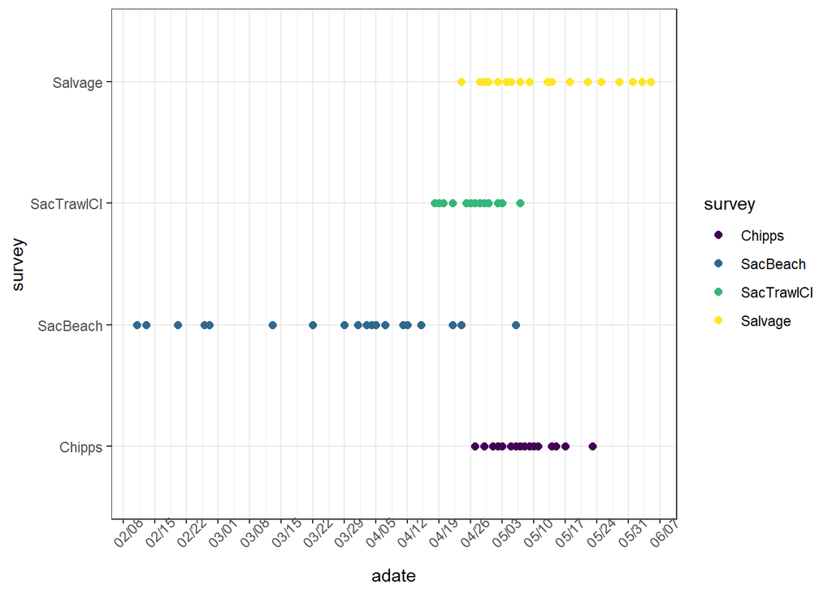

```r
ggplot() +
  geom_point(data = dateDiff, aes(x=adate, y= survey, color = survey), size = 2)+
  scale_x_date(date_breaks="weeks",
               labels = date_format("%m/%d")) +
  scale_color_viridis(discrete=TRUE) +
  theme_bw() +
  theme(axis.text.x = element_text(angle=45))
```

Timing of 95% salvage by water year type and brood year

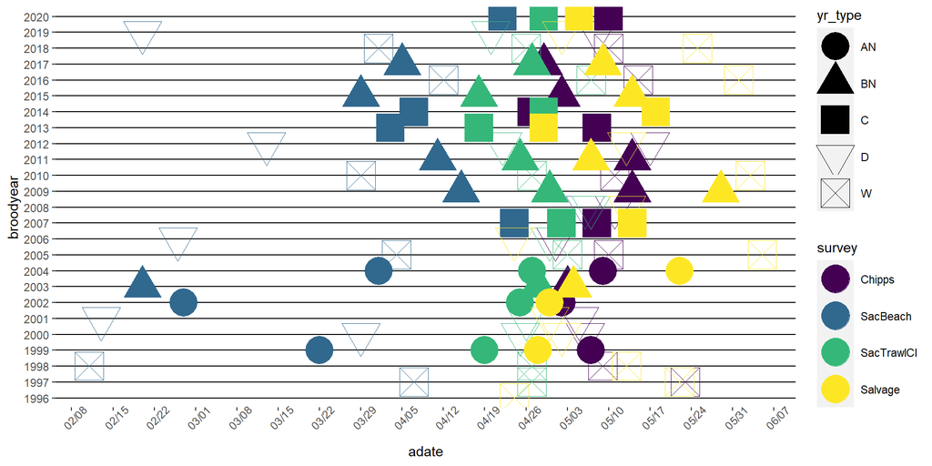

```r
ggplot(nf.per, aes(x=adate, y= broodyear, color = survey, shape = yr_type))+
  geom_point(size = 10, na.rm = TRUE)+
  scale_x_date(date_breaks = "weeks",
               labels = date_format("%m/%d")) +
  scale_color_viridis(discrete = TRUE) +
  scale_shape_manual(values=c(16, 17, 15, 6, 7))+
  theme(axis.text.x = element_text(angle=45),panel.background = element_rect(fill = 'white'),
        panel.grid.major = element_line(color = 'black'))+
    removeGrid(y=FALSE)
```

## Mean date

Mean 95% dates by water year type

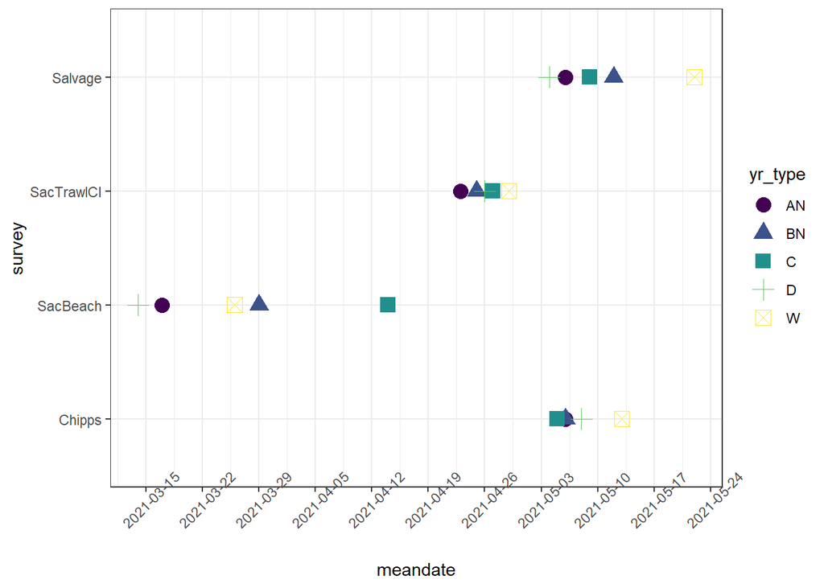

```r
ggplot(meanDateWYType) +
  geom_point(aes(x = meandate, y = survey, color = yr_type, shape = yr_type), size = 4) +
  scale_x_date(date_breaks = "1 week") +
  scale_color_viridis(discrete = TRUE) +
  theme_bw() +
  theme(axis.text.x = element_text(angle = 45))
```

Another view (boxplot/median)

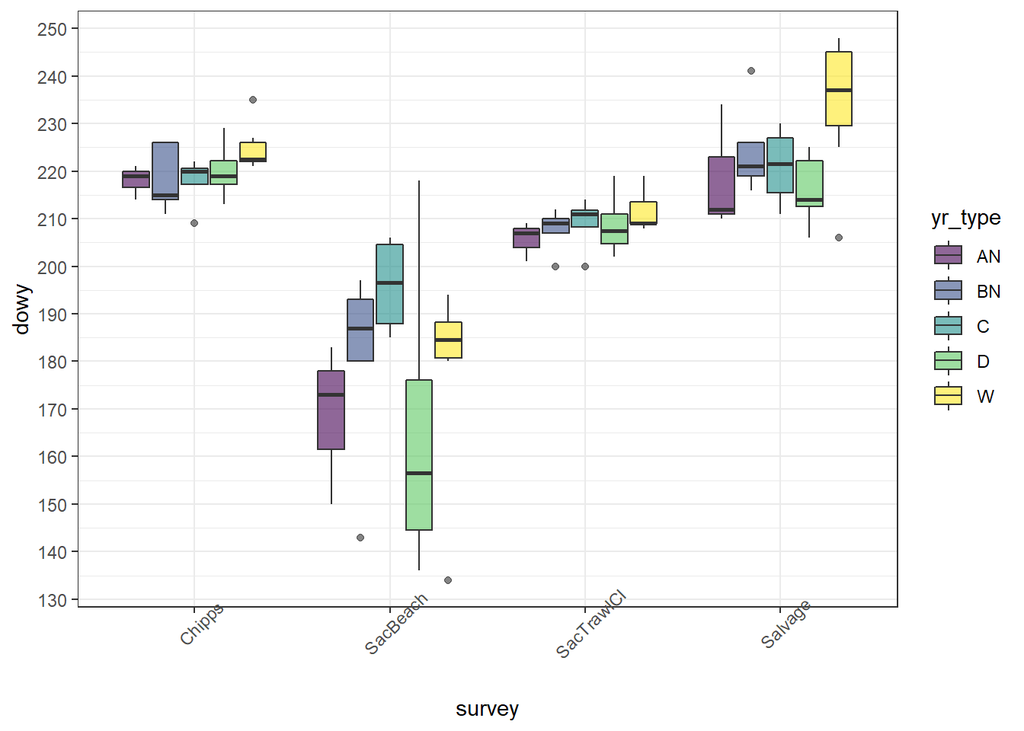

```r
ggplot(nf.per) +
  geom_boxplot(aes(x = survey, y = dowy, fill = yr_type), alpha = 0.6) +
  scale_fill_viridis(discrete = TRUE) +
  scale_y_continuous(breaks = seq(100, 250, by = 10))+
  theme_bw() +
  theme(axis.text.x = element_text(angle = 45))
```

How dates deviate from mean

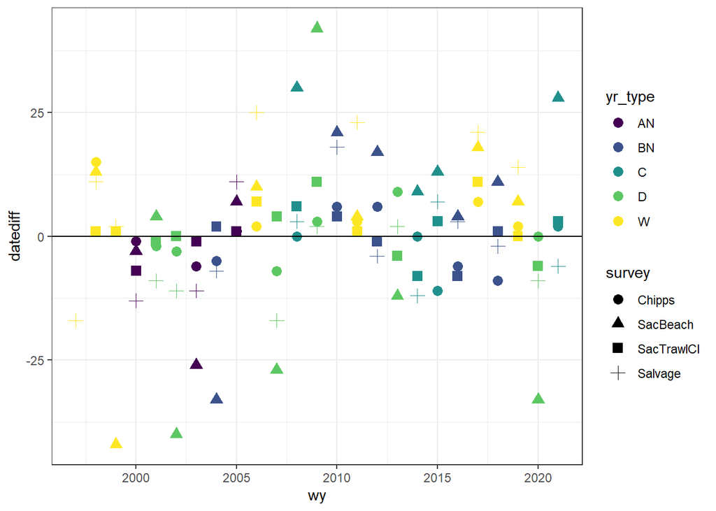

```r
ggplot(dateDiff) +
  geom_point(aes(x = wy, y = datediff, color = yr_type, shape = survey), size = 3)+
  geom_hline(yintercept = 0) +
  scale_color_viridis(discrete = TRUE) + theme_bw()
```

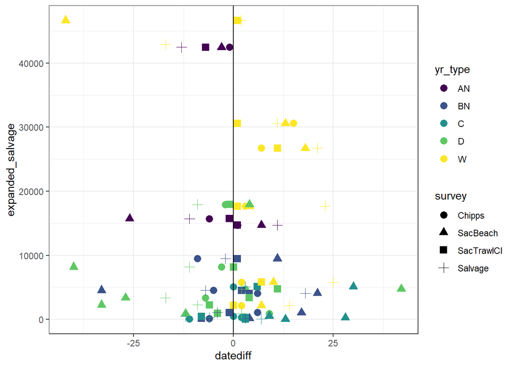

```r
ggplot(dateDiff) +
  geom_point(aes(x = datediff, y = expanded_salvage, color = yr_type, shape = survey), size = 3) +
  #geom_smooth(aes(x = datediff, y = expanded_salvage, color = survey)) +
  geom_vline(xintercept = 0) +
  scale_color_viridis(discrete = TRUE) +
  theme_bw()
```

## Relationships

Deviation from mean date vs. Expanded Salvage **need some kind of standardization for expanded salvage - escapement?**

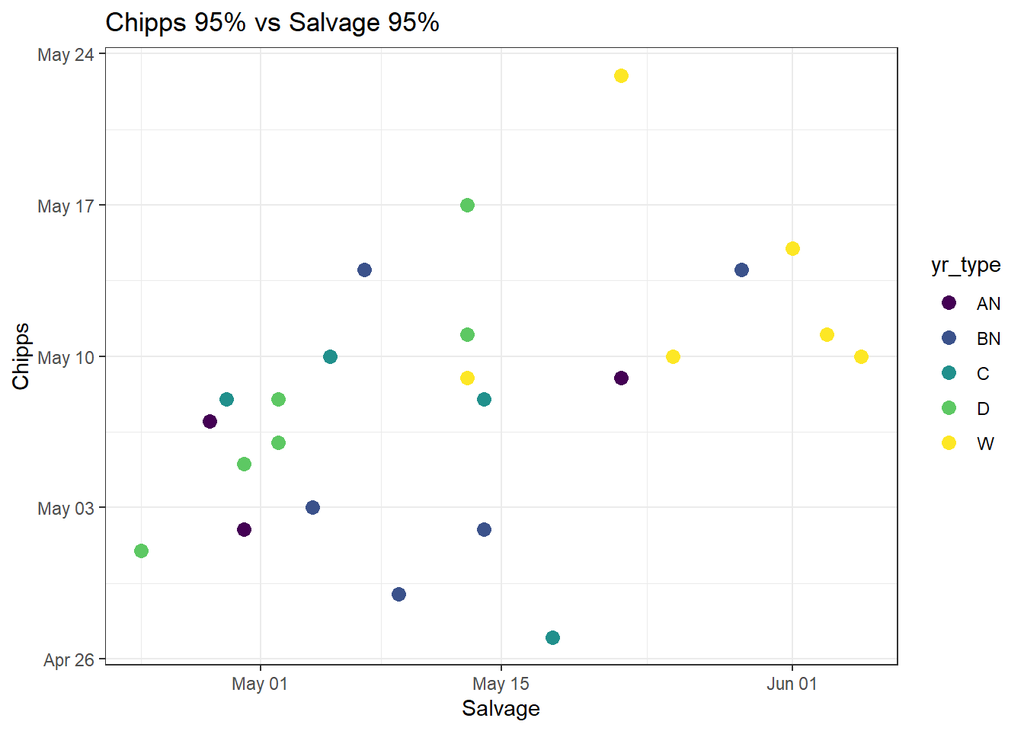

```r
ggplot(dates_wide) +
  geom_point(aes(x = Salvage, y = Chipps, color = yr_type), size = 3) +
  #geom_smooth(aes(Salvage, Chipps), formula = "lm") +
  scale_color_viridis(discrete = TRUE) +
  labs(title = "Chipps 95% vs Salvage 95%") +
  theme_bw()
```

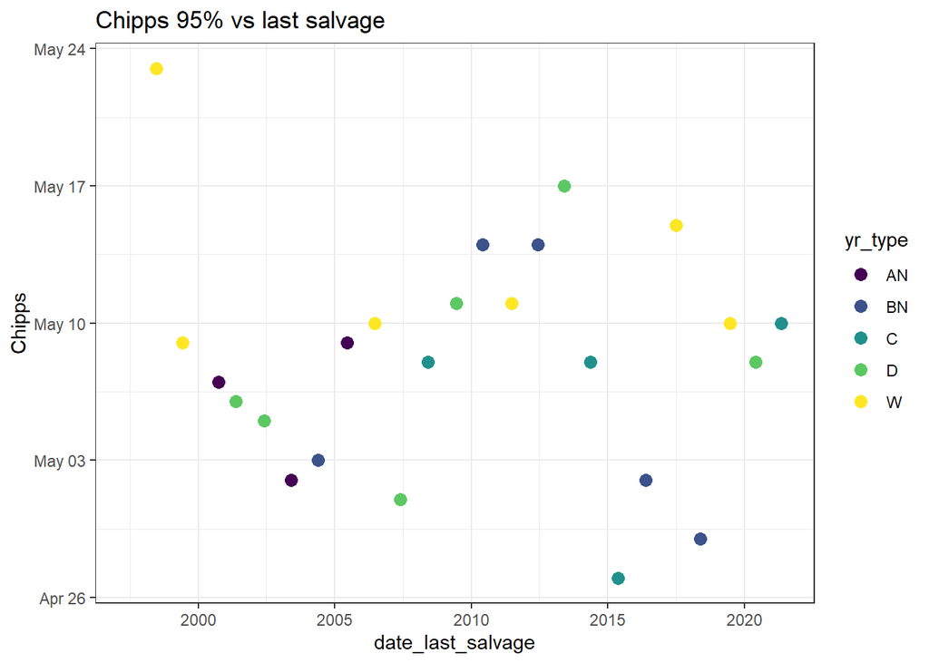

```r
ggplot(dates_wide) +
  geom_point(aes(x = date_last_salvage, y = Chipps, color = yr_type), size = 3) +
  #geom_smooth(aes(x = datediff, y = expanded_salvage, color = survey)) +
  scale_color_viridis(discrete = TRUE) +
  labs(title = "Chipps 95% vs last salvage")+
  theme_bw()
```

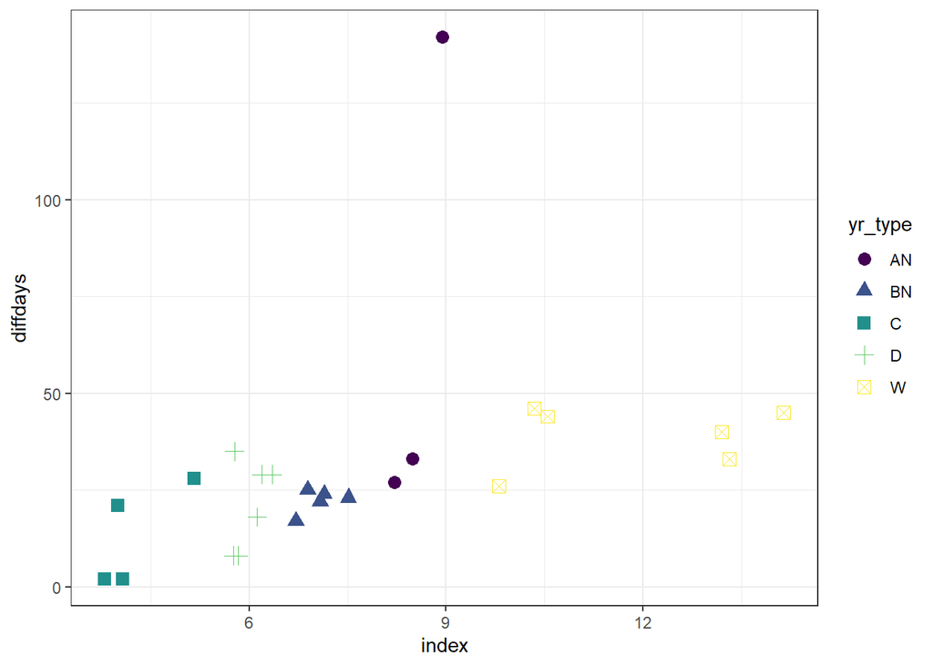

```r
ggplot(chipps_salvage) +
  geom_point(aes(x = index, diffdays, color = yr_type, shape = yr_type), size = 3)+
  scale_color_viridis(discrete = TRUE) +
  theme_bw()
```

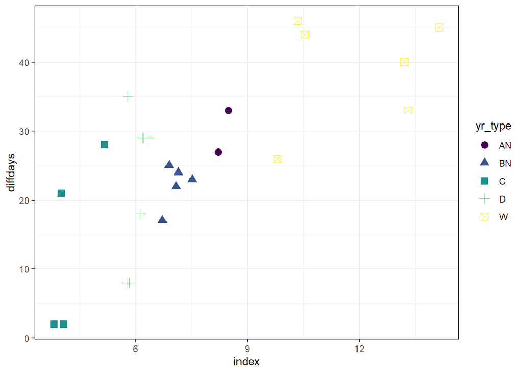

```r
chipps_salvage2 <- chipps_salvage %>%
  filter(diffdays<100)

  ggplot(chipps_salvage2) +
  geom_point(aes(x = index, y = diffdays, color = yr_type, shape = yr_type), size = 3)+
  scale_color_viridis(discrete = TRUE) +
  theme_bw()
```

```r
model <- lm(index~ diffdays, data = chipps_salvage2)
summary(model)
```

```
##
## Call:
## lm(formula = index ~ diffdays, data = chipps_salvage2)
##
## Residuals:
##     Min      1Q  Median      3Q     Max
## -3.5736 -0.8266  0.0140  0.8406  4.3083
##
## Coefficients:
##             Estimate Std. Error t value Pr(>|t|)
## (Intercept)  3.19478    0.96023   3.327   0.0032 **
## diffdays     0.17597    0.03399   5.177 3.95e-05 ***
## ---
## Signif. codes:  0 '***' 0.001 '**' 0.01 '*' 0.05 '.' 0.1 ' ' 1
##
## Residual standard error: 2.004 on 21 degrees of freedom
## Multiple R-squared:  0.5607, Adjusted R-squared:  0.5397
## F-statistic:  26.8 on 1 and 21 DF,  p-value: 3.952e-05
```

# Conclusions

- Average date for 95% at Chipps: 2021-05-08
- Last 95% date for Chipps is 2021-05-23 (always before June 30)
- Last date of salvage is generally end of June (one weird year in Sept)
- Greater diff between 95% and last salvage during wetter years

# Next steps

- Figure out relationship of grandtab with data to see if we can use proportion of escapement to compare to 95% at Chipps
- Should we compare RT monitoring group percentages with the true percentages?
- Should we compare the real catch data with 95% at Chipps or instances of catch (tapering off)?
- Days from June 30 by water year type
- Compare water quality with percentages? Is wt good at predicting last salvage?

# Knowns by the RT Monitoring Group

- Number fish caught so far

# Unknowns by RT Monitoring Group

- What water year type it is
- What is the total number of fish for that year